# CA4 - PART $\color{blue}{ONE}$

## $\color{orange}{Borna}$ Tavassoli

### 810198374

## $\color{orange}{Part 1:}$ Preprocessing

```python
import pandas as pd
import numpy as np
import matplotlib.pyplot as plt
import cv2
```

```python
dataframe = pd.read_csv('labels.csv')
dataframe
```

|  | id | label |
| --- | --- | --- |
| 0 | 8 | horse |
| 1 | 10 | cat |
| 2 | 12 | horse |
| 3 | 13 | horse |
| 4 | 18 | cat |
| ... | ... | ... |
| 9995 | 49979 | horse |
| 9996 | 49980 | cat |
| 9997 | 49983 | cat |
| 9998 | 49984 | cat |
| 9999 | 49987 | horse |

10000 rows × 2 columns

```python
TRAIN_SIZE = 8000
TEST_SIZE = 2000

train_df = pd.DataFrame()
test_df = pd.DataFrame()

for i in range(TRAIN_SIZE):
    id_ = dataframe['id'][i]
    img = cv2.imread(".\data\\" + str(id_) + ".png", cv2.IMREAD_GRAYSCALE)
    data = {'id': id_, 'value': [img], 'type': dataframe['label'][i]}
    train_df = train_df.append(pd.DataFrame(data), ignore_index=True)

for i in range(TEST_SIZE):
    id_ = dataframe['id'][TRAIN_SIZE + i]
    img = cv2.imread(".\data\\" + str(id_) + ".png", cv2.IMREAD_GRAYSCALE)
    data = {'id': id_, 'value': [img], 'type': dataframe['label'][TRAIN_SIZE + i]}
    test_df = test_df.append(pd.DataFrame(data), ignore_index=True)

train_df['value'] = train_df['value'] / 255
test_df['value'] = test_df['value'] / 255
```

The above code is all the preprocessing we need for our neural network. In the next few sections, we use train_test_split to see some random samples and work with min_max_scaler as a different tool of scaling!

1. Here we read a random picture and extract the dimesntions. We can see that each pixel is a tuple of integers between 0 and 255.

```
[[104, 66, 75],
 [101, 58, 68],
 [97, 56, 65],
 [98, 56, 65],
 [120, 91, 96],
 [121, 94, 98],
 [109, 75, 81],
 [88, 43, 49],
 [115, 78, 81],
 [102, 63, 66]]
```

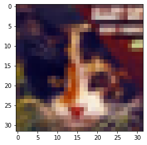

```python
from PIL import Image
from sklearn.model_selection import train_test_split
train_x, test_x, train_y, test_y = train_test_split(dataframe['id'], dataframe['label'], test_size=0.2, random_state=42)

test_picture_id = train_x.values[17] #just a random id!
test_picture = Image.open('data\\' + str(test_picture_id) + '.png')

plt.imshow(test_picture)
pixels = [list(pixel) for pixel in test_picture.getdata()]
pixels[20:30]
```

1. We can see a random image from both classes (horse and cat) in our train dataset as below:

```
Picture class is: cat
```

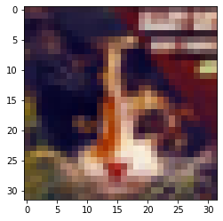

```python
test_picture_id_class_cat = train_x.values[17] #just a random id!
test_picture_cat = Image.open('data\\' + str(test_picture_id_class_cat) + '.png')

print("Picture class is:", train_y.values[17])
plt.figure()
plt.imshow(test_picture_cat)
plt.show()
```

```
Picture class is: horse
```

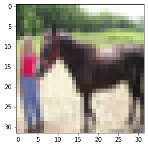

```python
test_picture_id_class_horse = train_x.values[27] #just a random id!
test_picture_horse = Image.open('data\\' + str(test_picture_id_class_horse) + '.png')

print("Picture class is:", train_y.values[27])
plt.figure()
plt.imshow(test_picture_horse)
plt.show()
```

1. We calculate the frequency of each class type in both train and test datasets.

```python
train_y.value_counts()
```

```
horse    4016
cat      3984
Name: label, dtype: int64
```

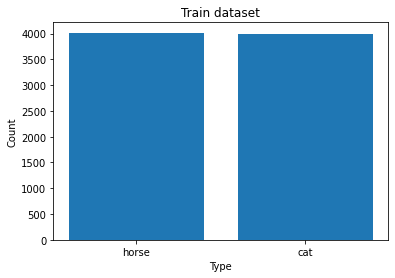

```python
data_train = {'horse': train_y.value_counts()['horse'], 'cat': train_y.value_counts()['cat']}
types = list(data_train.keys())
values_train = list(data_train.values())
plt.bar(types, values_train)
plt.xlabel("Type")
plt.ylabel("Count")
plt.title("Train dataset")
plt.show()
```

```python
test_y.value_counts()
```

```
cat      1016
horse     984
Name: label, dtype: int64
```

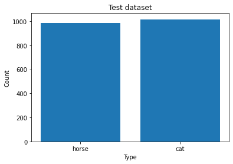

```python
data_test = {'horse': test_y.value_counts()['horse'], 'cat': test_y.value_counts()['cat']}
types = list(data_test.keys())
values_test = list(data_test.values())
plt.bar(types, values_test)
plt.xlabel("Type")
plt.ylabel("Count")
plt.title("Test dataset")
plt.show()
```

1. Now we convert our pictures to black and white and then rescale the pixels so that each pixel would be between 0 and 1. If we don't do this step, our features would lose their impacts moving forward and the activation functions would be obsolete.

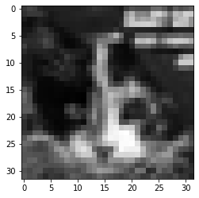

```python
bnw_images = []
for image_id in train_x.values:
    bnw_image = Image.open('data\\' + str(image_id) + '.png').convert('L')
    bnw_images.append(list(bnw_image.getdata()))
    bnw_image.close()

for image_id in test_x.values:
    bnw_image = Image.open('data\\' + str(image_id) + '.png').convert('L')
    bnw_images.append(list(bnw_image.getdata()))
    bnw_image.close()

bnw_image = Image.open('data\\' + str(train_x.values[17]) + '.png').convert('L')

plt.figure()
plt.imshow(bnw_image, cmap='gray')
plt.show()
```

```python
from sklearn.preprocessing import MinMaxScaler
min_max_scaler = MinMaxScaler()
min_max_scaler.fit(bnw_images)
bnw_images_scaled = min_max_scaler.transform(bnw_images)
bnw_images_scaled
```

```
array([[0.49019608, 0.49803922, 0.50980392, ..., 0.49019608, 0.45098039,
        0.44313725],
       [0.52156863, 0.51372549, 0.51764706, ..., 0.29411765, 0.28627451,
        0.28627451],
       [0.04313725, 0.03921569, 0.13333333, ..., 0.05882353, 0.04705882,
        0.03529412],
       ...,
       [0.78039216, 0.75294118, 0.74901961, ..., 0.71372549, 0.68235294,
        0.62745098],
       [0.35686275, 0.32941176, 0.34901961, ..., 0.22352941, 0.19215686,
        0.25098039],
       [0.24313725, 0.25098039, 0.2627451 , ..., 0.61960784, 0.58823529,
        0.58823529]])
```

```python
scaled_df = pd.DataFrame(bnw_images_scaled)
scaled_df
```

|  | 0 | 1 | 2 | 3 | 4 | 5 | 6 | 7 | 8 | 9 | ... | 1014 | 1015 | 1016 | 1017 | 1018 | 1019 | 1020 | 1021 | 1022 | 1023 |
| --- | --- | --- | --- | --- | --- | --- | --- | --- | --- | --- | --- | --- | --- | --- | --- | --- | --- | --- | --- | --- | --- |
| 0 | 0.490196 | 0.498039 | 0.509804 | 0.498039 | 0.498039 | 0.466667 | 0.427451 | 0.403922 | 0.427451 | 0.450980 | ... | 0.658824 | 0.509804 | 0.400000 | 0.439216 | 0.439216 | 0.439216 | 0.513725 | 0.490196 | 0.450980 | 0.443137 |
| 1 | 0.521569 | 0.513725 | 0.517647 | 0.533333 | 0.541176 | 0.552941 | 0.576471 | 0.584314 | 0.596078 | 0.643137 | ... | 0.298039 | 0.305882 | 0.298039 | 0.278431 | 0.278431 | 0.282353 | 0.290196 | 0.294118 | 0.286275 | 0.286275 |
| 2 | 0.043137 | 0.039216 | 0.133333 | 0.298039 | 0.364706 | 0.384314 | 0.396078 | 0.400000 | 0.415686 | 0.423529 | ... | 0.023529 | 0.015686 | 0.035294 | 0.035294 | 0.047059 | 0.050980 | 0.054902 | 0.058824 | 0.047059 | 0.035294 |
| 3 | 0.023529 | 0.011765 | 0.011765 | 0.011765 | 0.019608 | 0.023529 | 0.023529 | 0.027451 | 0.035294 | 0.035294 | ... | 0.470588 | 0.482353 | 0.564706 | 0.603922 | 0.596078 | 0.572549 | 0.556863 | 0.560784 | 0.564706 | 0.556863 |
| 4 | 0.631373 | 0.611765 | 0.603922 | 0.596078 | 0.592157 | 0.588235 | 0.552941 | 0.509804 | 0.509804 | 0.419608 | ... | 0.125490 | 0.039216 | 0.094118 | 0.145098 | 0.250980 | 0.321569 | 0.345098 | 0.400000 | 0.541176 | 0.741176 |
| ... | ... | ... | ... | ... | ... | ... | ... | ... | ... | ... | ... | ... | ... | ... | ... | ... | ... | ... | ... | ... | ... |
| 9995 | 0.207843 | 0.407843 | 0.784314 | 0.850980 | 0.792157 | 0.717647 | 0.698039 | 0.749020 | 0.682353 | 0.733333 | ... | 0.309804 | 0.329412 | 0.321569 | 0.372549 | 0.376471 | 0.317647 | 0.290196 | 0.274510 | 0.286275 | 0.329412 |
| 9996 | 0.709804 | 0.713725 | 0.725490 | 0.741176 | 0.749020 | 0.764706 | 0.780392 | 0.772549 | 0.772549 | 0.788235 | ... | 0.329412 | 0.337255 | 0.341176 | 0.325490 | 0.337255 | 0.345098 | 0.341176 | 0.349020 | 0.352941 | 0.337255 |
| 9997 | 0.780392 | 0.752941 | 0.749020 | 0.713725 | 0.654902 | 0.556863 | 0.462745 | 0.368627 | 0.247059 | 0.203922 | ... | 0.737255 | 0.741176 | 0.745098 | 0.752941 | 0.733333 | 0.690196 | 0.701961 | 0.713725 | 0.682353 | 0.627451 |
| 9998 | 0.356863 | 0.329412 | 0.349020 | 0.349020 | 0.341176 | 0.325490 | 0.313725 | 0.298039 | 0.298039 | 0.313725 | ... | 0.188235 | 0.188235 | 0.188235 | 0.278431 | 0.427451 | 0.380392 | 0.325490 | 0.223529 | 0.192157 | 0.250980 |
| 9999 | 0.243137 | 0.250980 | 0.262745 | 0.298039 | 0.294118 | 0.305882 | 0.325490 | 0.317647 | 0.313725 | 0.345098 | ... | 0.611765 | 0.603922 | 0.588235 | 0.588235 | 0.592157 | 0.592157 | 0.650980 | 0.619608 | 0.588235 | 0.588235 |

10000 rows × 1024 columns

## $\color{orange}{Part 2:}$ Complete the code

# Dataloader

```python
class Dataloader:

    def __init__(self, data, labels, n_classes, batch_size=None, shuffle=False):
        assert len(data)==len(labels)
        self.__n_classes = n_classes
        self.__batch_size = batch_size
        self.__shuffle = shuffle
        self.__data = data
        self.__onehot_labels = self.__onehot(labels, self.__n_classes)

    def __onehot(self, labels, n_classes):
        onehot_vectors = []
        for label in labels:
            onehot_vector = [0] * n_classes
            index = 1 if label == 'horse' else 0
            onehot_vector[index] = 1
            onehot_vectors.append(onehot_vector)

        return onehot_vectors

    def __shuffle_dataset(self):
        self.__data = self.__data.sample(frac = 1)

    def __iter__(self):

        if self.__shuffle:
            self.__shuffle_dataset()

        if self.__batch_size==None:
            yield (np.matrix(self.__data), np.matrix(self.__onehot_labels))
            return

        for idx in range(0, len(self.__data), self.__batch_size):
            yield (np.matrix(self.__data[idx:idx+self.__batch_size]),
                   np.matrix(self.__onehot_labels[idx:idx+self.__batch_size]))
```

# Activation Functions

```python
class Identical:

    def __init__(self):
        pass

    def __val(self, matrix):
        identical_value = np.matrix(matrix, dtype=float)
        return identical_value

    def derivative(self, matrix):
        temp = np.matrix(matrix, dtype=float)
        identical_derivative = np.matrix(np.full(np.shape(temp), 1.))
        return identical_derivative

    def __call__(self, matrix):
        return self.__val(matrix)


class Relu:

    def __init__(self):
        pass

    def __val(self, matrix):
        relu_value = matrix.copy()
        relu_value[relu_value < 0] = 0
        return relu_value

    def derivative(self, matrix):
        relu_derivative = matrix.copy()
        relu_derivative[relu_derivative < 0] = 0
        relu_derivative[relu_derivative > 0] = 1
        return relu_derivative

    def __call__(self, matrix):
        return self.__val(matrix)


class LeakyRelu:

    def __init__(self, negative_slope=0.01):
        self.negative_slope = 0.01

    def __val(self, matrix):
        leacky_relu_value = matrix.copy()
        leacky_relu_value = np.where(leacky_relu_value > 0, leacky_relu_value, 0.01 * leacky_relu_value)
        return leacky_relu_value

    def derivative(self, matrix):
        leacky_relu_derivative = matrix.copy()
        leacky_relu_derivative = np.where(leacky_relu_derivative > 0, 1, 0.01)
        return leacky_relu_derivative

    def __call__(self, matrix):
        return self.__val(matrix)


class Sigmoid:

    def __init__(self):
        pass

    def __val(self, matrix):

        sigmoid_value = 1.0 / (1.0 + np.exp(-matrix))
        return sigmoid_value

    def derivative(self, matrix):

        sigmoid_value = self.__val(matrix)
        sigmoid_derivative = np.multiply(sigmoid_value, 1 - sigmoid_value)
        return sigmoid_derivative

    def __call__(self, matrix):

        return self.__val(matrix)


class Softmax:

    def __init__(self):
        pass

    def __val(self, matrix):

        softmax_value = np.zeros(matrix.shape)
        for i in range(0, len(matrix)):
            softmax_value[i] = np.exp(matrix[i] - np.max(matrix[i])) #stable softmax
            softmax_value[i] /= np.sum(softmax_value[i])
        return softmax_value

    def __call__(self, matrix):
        return self.__val(matrix)

class Tanh:

    def __init__(self):
        pass

    def __val(self, matrix):
        tanh_value = np.tanh(matrix)
        return tanh_value

    def derivative(self, matrix):
        tanh_value = self.__val(matrix)
        tanh_derivative = 1 - np.multiply(tanh_value, tanh_value)
        return tanh_derivative

    def __call__(self, matrix):
        return self.__val(matrix)
```


# Loss Function

```python
BIAS = 1e-10
class CrossEntropy: #(with softmax)
    def __init__(self):
        pass

    def __val(self, true_val, expected_val):

        assert np.shape(true_val)==np.shape(expected_val)
        softmax = Softmax()
        cross_entropy_value = np.sum(-np.multiply(expected_val, np.log(softmax(true_val + BIAS) + BIAS)), axis=1)
        return cross_entropy_value

    def derivative(self, true_val, expected_val):
        assert np.shape(true_val)==np.shape(expected_val)
        softmax = Softmax()
        cross_entropy_derivative = softmax(true_val) - expected_val
        return cross_entropy_derivative

    def __call__(self, true_val, expected_val):
        return self.__val(true_val, expected_val)
```

# Layer

```python
class Layer:

    DEFAULT_LOW, DEFAULT_HIGH, DEFAULT_MEAN, DEFAULT_VAR = 0, 0.05, 0., 1.

    def __init__(self, input_size, output_size, activation=Identical(), initial_weight='uniform',
                 **initializing_parameters):
        assert type(initial_weight)==str, 'Undefined activation function!'

        self.__weight_initializer_dict = {'uniform':self.__uniform_weight, 'normal':self.__normal_weight}

        assert initial_weight in self.__weight_initializer_dict, 'Undefined weight initialization function!'


        self.__n_neurons = output_size
        weight_initializer = self.__weight_initializer_dict[initial_weight]
        self.__weight = weight_initializer(input_size, self.__n_neurons, **initializing_parameters)
        self.__bias = weight_initializer(1, self.__n_neurons, **initializing_parameters)
        self.__activation = activation

        self.__last_input = None
        self.__last_activation_input = None
        self.__last_activation_output = None
        self.__last_activation_derivative = None

    def forward(self, layer_input):
        assert np.ndim(layer_input)==2
        assert np.size(self.__weight,0) == np.size(layer_input,1)

        self.__last_input = layer_input.copy()

        self.__last_activation_input = np.add(np.dot(layer_input, self.__weight), self.__bias)
        self.__last_activation_output = self.__activation(self.__last_activation_input)
        self.__last_activation_derivative = self.activation.derivative(self.__last_activation_input)
        return self.__last_activation_output

    def update_weights(self, backprop_tensor, lr):
        assert np.ndim(backprop_tensor)==2
        assert np.size(backprop_tensor,0) == np.size(self.__last_activation_derivative,0)
        assert np.size(backprop_tensor,1) == self.__n_neurons

        backprop_tensor_copy = backprop_tensor.copy()
        dL_dy = np.multiply(backprop_tensor_copy, self.__last_activation_derivative)
        backprop_tensor = np.dot(dL_dy, self.__weight.transpose()) #dL_dx

        dL_dW = np.dot(self.__last_input.T, dL_dy)
        self.__weight -= (lr * dL_dW)

        ones_ = np.ones((1, dL_dy.shape[0]))
        dL_db = np.dot(ones_, dL_dy)
        self.__bias -= (lr * dL_db)

        return backprop_tensor

    def __uniform_weight(self, dim1, dim2, **initializing_parameters):
        low, high = self.DEFAULT_LOW, self.DEFAULT_HIGH
        if 'low' in initializing_parameters.keys(): low = initializing_parameters['low']
        if 'high' in initializing_parameters.keys(): high = initializing_parameters['high']

        weights = np.random.uniform(low = low, high = high, size = (dim1, dim2))

        return weights

    def __normal_weight(self, dim1, dim2, **initializing_parameters):
        mean, var = self.DEFAULT_MEAN, self.DEFAULT_VAR
        if 'mean' in initializing_parameters.keys(): mean = initializing_parameters['mean']
        if 'var' in initializing_parameters.keys(): var = initializing_parameters['var']

        weights = np.random.normal(loc = mean, scale = np.sqrt(var), size=(dim1, dim2))

        return weights

    @property
    def n_neurons(self): return self.__n_neurons

    @property
    def weight(self): return self.__weight

    @property
    def bias(self): return self.__bias

    @property
    def activation(self): return self.__activation
```

Further reading about the implementation can be found here: $\href{https://towardsdatascience.com/understanding-backpropagation-algorithm-7bb3aa2f95fd}{link}$

# Feed Forward Neural Network

```python
class FeedForwardNN:

    def __init__(self, input_shape):
        self.__input_shape = input_shape
        self.__output_shape = None

        self.__layers_list = []

        self.__lr = None
        self.__loss = None


    def add_layer(self, n_neurons, activation=Relu(), initial_weight='uniform', **initializing_parameters):
        assert type(n_neurons)==int, "Invalid number of neurons for the layer!"
        assert n_neurons>0, "Invalid number of neurons for the layer!"

        n_prev_neurons = self.__input_shape if len(self.__layers_list)==0 else self.__layers_list[-1].n_neurons
        new_layer = Layer(n_prev_neurons, n_neurons, activation, initial_weight, **initializing_parameters)
        self.__layers_list.append(new_layer)
        self.__output_shape = self.__layers_list[-1].n_neurons


    def set_training_param(self, loss=CrossEntropy(), lr=1e-3):
        assert self.__layers_list, "Uncomplete model!"
        self.__loss = loss
        self.__lr = lr


    def forward(self, network_input):
        assert type(self.__output_shape) != None, "Model is not compiled!"

        network_output = network_input.copy()
        for layer in self.__layers_list:
            network_output = layer.forward(network_output)

        return network_output


    def fit(self, epochs, trainloader, testloader=None, print_results=True):
        assert type(self.__output_shape) != None, "Model is not compiled!"
        assert type(self.__lr) != None and type(self.__loss) != None, "Training paramenters are not set!"

        log = {"train_accuracy":[], "train_loss":[], "test_accuracy":[], "test_loss":[]}

        for epoch in range(1, epochs+1):

            if print_results:
                print('Epoch {}:'.format(epoch))

            average_accuracy, average_loss = self.__train(trainloader)
            log['train_accuracy'].append(average_accuracy)
            log['train_loss'].append(average_loss)
            if print_results:
                print('\tTrain: Average Accuracy: {}\tAverage Loss: {}'.format(average_accuracy, average_loss))

            if type(testloader) != type(None):
                average_accuracy, average_loss = self.__test(testloader)
                log['test_accuracy'].append(average_accuracy)
                log['test_loss'].append(average_loss)
                if print_results:
                    print('\tTest: Average Accuracy: {}\tAverage Loss: {}'.format(average_accuracy, average_loss))

        return log


    def __train(self, trainloader):
        batch_accuracies, batch_losses = [], []
        for x_train, y_train in trainloader:
            batch_accuracy, batch_loss = self.__train_on_batch(x_train, y_train)
            batch_accuracies.append(batch_accuracy)
            batch_losses.append(batch_loss)
        return np.mean(batch_accuracies), np.mean(batch_losses)


    def __test(self, testloader):
        batch_accuracies, batch_losses = [], []
        for x_test, y_test in testloader:
            batch_accuracy, batch_loss = self.__test_on_batch(x_test, y_test)
            batch_accuracies.append(batch_accuracy)
            batch_losses.append(batch_loss)

        return np.mean(batch_accuracies), np.mean(batch_losses)


    def __train_on_batch(self, x_batch, y_batch):
        batch_out = self.forward(x_batch)
        batch_accuracy = self.__compute_accuracy(batch_out, y_batch)
        batch_average_loss = np.mean(self.__loss(batch_out, y_batch))
        self.__update_weights(batch_out, y_batch)

        return (batch_accuracy, batch_average_loss)


    def __test_on_batch(self, x_batch, y_batch):
        batch_out = self.forward(x_batch)
        batch_accuracy = self.__compute_accuracy(batch_out, y_batch)
        batch_average_loss = np.mean(self.__loss(batch_out, y_batch))

        return (batch_accuracy, batch_average_loss)


    def __get_labels(self, outputs):
        labels = outputs.argmax(axis=1)

        return labels


    def __compute_accuracy(self, output, expected_output):
        generated_l = self.__get_labels(output)
        true_l = self.__get_labels(expected_output)
        accuracy = ((generated_l == true_l).sum() / output.shape[0])

        return accuracy


    def __update_weights(self, output, y_train):
        gradiant = self.__loss.derivative(output, y_train)
        for layer in reversed(self.__layers_list):
            gradiant = layer.update_weights(gradiant, self.__lr)

        return
```

## $\color{orange}{Part 3:}$ Experimenting

# Training Sample Code

```python
columns_ = [i for i in range(0, 1024)]

train_rows = [np.reshape(row, 1024) for row in train_df['value']]
train_neurons = pd.DataFrame(train_rows, columns=columns_)
test_rows = [np.reshape(row, 1024) for row in test_df['value']]
test_neurons = pd.DataFrame(test_rows, columns=columns_)

INPUT_SHAPE = 1024
LEARNING_RATE = 0.001
EPOCHS = 15

TRAINLOADER = Dataloader(data = train_neurons, labels = train_df['type'], n_classes = 2, batch_size = 32 , shuffle=False)
TESTLOADER =  Dataloader(data = test_neurons, labels = test_df['type'], n_classes = 2, batch_size = 32 , shuffle=False)

network = FeedForwardNN(INPUT_SHAPE)
network.add_layer(30, input_shape=INPUT_SHAPE, activation=Relu(), weight_initializer='uniform')
network.add_layer(2, activation=Identical(), weight_initializer='uniform')
network.set_training_param(loss=CrossEntropy(), lr=LEARNING_RATE)
log = network.fit(EPOCHS, TRAINLOADER, TESTLOADER)
```

```
Epoch 1:
	Train: Average Accuracy: 0.522125	Average Loss: 1.271376482552112
	Test: Average Accuracy: 0.5625	Average Loss: 0.6782998508334414
Epoch 2:
	Train: Average Accuracy: 0.595375	Average Loss: 0.6665881004739962
	Test: Average Accuracy: 0.5902777777777778	Average Loss: 0.6570259553571399
Epoch 3:
	Train: Average Accuracy: 0.62375	Average Loss: 0.6474675452030517
	Test: Average Accuracy: 0.6111111111111112	Average Loss: 0.6462117624581805
Epoch 4:
	Train: Average Accuracy: 0.644625	Average Loss: 0.6276725442039333
	Test: Average Accuracy: 0.6175595238095238	Average Loss: 0.6385725869882777
Epoch 5:
	Train: Average Accuracy: 0.66725	Average Loss: 0.6053766300947795
	Test: Average Accuracy: 0.6557539682539683	Average Loss: 0.6093899603379977
Epoch 6:
	Train: Average Accuracy: 0.68375	Average Loss: 0.5871797906746813
	Test: Average Accuracy: 0.6651785714285714	Average Loss: 0.6051064256802074
Epoch 7:
	Train: Average Accuracy: 0.693625	Average Loss: 0.5735680302910241
	Test: Average Accuracy: 0.6790674603174603	Average Loss: 0.5902946483301772
Epoch 8:
	Train: Average Accuracy: 0.703125	Average Loss: 0.5619077302872509
	Test: Average Accuracy: 0.7028769841269841	Average Loss: 0.5726166530382198
Epoch 9:
	Train: Average Accuracy: 0.710375	Average Loss: 0.552673527658048
	Test: Average Accuracy: 0.716765873015873	Average Loss: 0.5626843024588181
Epoch 10:
	Train: Average Accuracy: 0.71925	Average Loss: 0.5444140029503902
	Test: Average Accuracy: 0.7137896825396826	Average Loss: 0.5588565968651041
Epoch 11:
	Train: Average Accuracy: 0.7225	Average Loss: 0.5370165755948431
	Test: Average Accuracy: 0.7306547619047619	Average Loss: 0.5462890815251434
Epoch 12:
	Train: Average Accuracy: 0.731625	Average Loss: 0.5305512203938922
	Test: Average Accuracy: 0.7385912698412699	Average Loss: 0.5446033566078152
Epoch 13:
	Train: Average Accuracy: 0.733375	Average Loss: 0.524787350561697
	Test: Average Accuracy: 0.7440476190476191	Average Loss: 0.5339364201590262
Epoch 14:
	Train: Average Accuracy: 0.7405	Average Loss: 0.5194348630385839
	Test: Average Accuracy: 0.751984126984127	Average Loss: 0.529930920314196
Epoch 15:
	Train: Average Accuracy: 0.742875	Average Loss: 0.5150586393944202
	Test: Average Accuracy: 0.746031746031746	Average Loss: 0.5258635542578708
```

1. We can see that the Test Accuracy is near 75 percent.
1. What if all the initial weights were zero?

If all the weights are initialized to zeros, the derivatives will remain same for every w in W[l]. As a result, neurons will learn same features in each iterations. This problem is known as network failing to break symmetry. On a more general note, if we initialize the weights with a constant, all of our nodes will end up with the same value and it will be no different than having just one node in the hidden layer. Because of this, our network would end up learning just one function while the goal of a neural network is to have different nodes compute different functions. To avoid such problem, we can initialize the weights randomly.

Further reading: $\href{https://medium.com/@safrin1128/weight-initialization-in-neural-network-inspired-by-andrew-ng-e0066dc4a566}{link}$

1. What impact does the learning rate play?

We know that learning rate has a direct relation with the value of our change. However, we need to find the proper learning rate such that our accuracy will be maximum. Here, we run our code for two (very) different learning rates.

```python
INPUT_SHAPE = 1024
LEARNING_RATE = 0.0001
EPOCHS = 15

TRAINLOADER = Dataloader(data = train_neurons, labels = train_df['type'], n_classes = 2, batch_size = 32 , shuffle=False)
TESTLOADER =  Dataloader(data = test_neurons, labels = test_df['type'], n_classes = 2, batch_size = 32 , shuffle=False)

network = FeedForwardNN(INPUT_SHAPE)
network.add_layer(30, input_shape=INPUT_SHAPE, activation=Relu(), weight_initializer='uniform')
network.add_layer(2, activation=Identical(), weight_initializer='uniform')
network.set_training_param(loss=CrossEntropy(), lr=LEARNING_RATE)
log = network.fit(EPOCHS, TRAINLOADER, TESTLOADER)
```

```
Epoch 1:
	Train: Average Accuracy: 0.500375	Average Loss: 2.878662129290621
	Test: Average Accuracy: 0.49007936507936506	Average Loss: 1.1562263810924656
Epoch 2:
	Train: Average Accuracy: 0.49775	Average Loss: 2.2229022230055295
	Test: Average Accuracy: 0.49007936507936506	Average Loss: 1.1274109937455008
Epoch 3:
	Train: Average Accuracy: 0.492	Average Loss: 1.710092477552093
	Test: Average Accuracy: 0.49007936507936506	Average Loss: 0.8856058288056159
Epoch 4:
	Train: Average Accuracy: 0.49325	Average Loss: 1.315950777299239
	Test: Average Accuracy: 0.49007936507936506	Average Loss: 0.8406823602752072
Epoch 5:
	Train: Average Accuracy: 0.497625	Average Loss: 1.0611411726451385
	Test: Average Accuracy: 0.4905753968253968	Average Loss: 0.7914349481225507
Epoch 6:
	Train: Average Accuracy: 0.499625	Average Loss: 0.9194840386865023
	Test: Average Accuracy: 0.4935515873015873	Average Loss: 0.7356204951870932
Epoch 7:
	Train: Average Accuracy: 0.514	Average Loss: 0.8336137026587267
	Test: Average Accuracy: 0.5252976190476191	Average Loss: 0.7023914024894841
Epoch 8:
	Train: Average Accuracy: 0.523625	Average Loss: 0.787930214596385
	Test: Average Accuracy: 0.5639880952380952	Average Loss: 0.6809380118518855
Epoch 9:
	Train: Average Accuracy: 0.5345	Average Loss: 0.7601359222854437
	Test: Average Accuracy: 0.5912698412698413	Average Loss: 0.6684785945249626
Epoch 10:
	Train: Average Accuracy: 0.5435	Average Loss: 0.7413059110556016
	Test: Average Accuracy: 0.6116071428571429	Average Loss: 0.6621478253300142
Epoch 11:
	Train: Average Accuracy: 0.55075	Average Loss: 0.7274489493452582
	Test: Average Accuracy: 0.6145833333333334	Average Loss: 0.6592093188146416
Epoch 12:
	Train: Average Accuracy: 0.557375	Average Loss: 0.7165233560450811
	Test: Average Accuracy: 0.6111111111111112	Average Loss: 0.6577936282490655
Epoch 13:
	Train: Average Accuracy: 0.561	Average Loss: 0.7074514461584145
	Test: Average Accuracy: 0.6046626984126984	Average Loss: 0.656903601702892
Epoch 14:
	Train: Average Accuracy: 0.5685	Average Loss: 0.6996562422308376
	Test: Average Accuracy: 0.6031746031746031	Average Loss: 0.6561191679867449
Epoch 15:
	Train: Average Accuracy: 0.575375	Average Loss: 0.6928266333609371
	Test: Average Accuracy: 0.5992063492063492	Average Loss: 0.6553329677639352
```

We can see that we're not taking as big steps as we should and therefore are moving very slowly (especially at the beginning). Our highest accuracy is around 60 percent.

```python
INPUT_SHAPE = 1024
LEARNING_RATE = 0.01
EPOCHS = 15

TRAINLOADER = Dataloader(data = train_neurons, labels = train_df['type'], n_classes = 2, batch_size = 32 , shuffle=False)
TESTLOADER =  Dataloader(data = test_neurons, labels = test_df['type'], n_classes = 2, batch_size = 32 , shuffle=False)

network = FeedForwardNN(INPUT_SHAPE)
network.add_layer(30, input_shape=INPUT_SHAPE, activation=Relu(), weight_initializer='uniform')
network.add_layer(2, activation=Identical(), weight_initializer='uniform')
network.set_training_param(loss=CrossEntropy(), lr=LEARNING_RATE)
log = network.fit(EPOCHS, TRAINLOADER, TESTLOADER)
```

```
Epoch 1:
	Train: Average Accuracy: 0.48775	Average Loss: 0.7363578356917857
	Test: Average Accuracy: 0.5099206349206349	Average Loss: 0.6929530999606475
Epoch 2:
	Train: Average Accuracy: 0.4875	Average Loss: 0.6950829939994452
	Test: Average Accuracy: 0.5099206349206349	Average Loss: 0.6929530999606475
Epoch 3:
	Train: Average Accuracy: 0.4875	Average Loss: 0.6950829939994452
	Test: Average Accuracy: 0.5099206349206349	Average Loss: 0.6929530999606475
Epoch 4:
	Train: Average Accuracy: 0.4875	Average Loss: 0.6950829939994452
	Test: Average Accuracy: 0.5099206349206349	Average Loss: 0.6929530999606475
Epoch 5:
	Train: Average Accuracy: 0.4875	Average Loss: 0.6950829939994452
	Test: Average Accuracy: 0.5099206349206349	Average Loss: 0.6929530999606475
Epoch 6:
	Train: Average Accuracy: 0.4875	Average Loss: 0.6950829939994452
	Test: Average Accuracy: 0.5099206349206349	Average Loss: 0.6929530999606475
Epoch 7:
	Train: Average Accuracy: 0.4875	Average Loss: 0.6950829939994452
	Test: Average Accuracy: 0.5099206349206349	Average Loss: 0.6929530999606475
Epoch 8:
	Train: Average Accuracy: 0.4875	Average Loss: 0.6950829939994452
	Test: Average Accuracy: 0.5099206349206349	Average Loss: 0.6929530999606475
Epoch 9:
	Train: Average Accuracy: 0.4875	Average Loss: 0.6950829939994452
	Test: Average Accuracy: 0.5099206349206349	Average Loss: 0.6929530999606475
Epoch 10:
	Train: Average Accuracy: 0.4875	Average Loss: 0.6950829939994452
	Test: Average Accuracy: 0.5099206349206349	Average Loss: 0.6929530999606475
Epoch 11:
	Train: Average Accuracy: 0.4875	Average Loss: 0.6950829939994452
	Test: Average Accuracy: 0.5099206349206349	Average Loss: 0.6929530999606475
Epoch 12:
	Train: Average Accuracy: 0.4875	Average Loss: 0.6950829939994452
	Test: Average Accuracy: 0.5099206349206349	Average Loss: 0.6929530999606475
Epoch 13:
	Train: Average Accuracy: 0.4875	Average Loss: 0.6950829939994452
	Test: Average Accuracy: 0.5099206349206349	Average Loss: 0.6929530999606475
Epoch 14:
	Train: Average Accuracy: 0.4875	Average Loss: 0.6950829939994452
	Test: Average Accuracy: 0.5099206349206349	Average Loss: 0.6929530999606475
Epoch 15:
	Train: Average Accuracy: 0.4875	Average Loss: 0.6950829939994452
	Test: Average Accuracy: 0.5099206349206349	Average Loss: 0.6929530999606475
```

This time, our steps are bigger than we needed so we can't actually improve the accuracy and miss the desired spot at each epoch.

In conclusion, 0.001 seems to be a good value for our learning rate.

1. Now we examine the impact of different activation functions.

```python
INPUT_SHAPE = 1024
LEARNING_RATE = 0.001
EPOCHS = 15

TRAINLOADER = Dataloader(data = train_neurons, labels = train_df['type'], n_classes = 2, batch_size = 32 , shuffle=False)
TESTLOADER =  Dataloader(data = test_neurons, labels = test_df['type'], n_classes = 2, batch_size = 32 , shuffle=False)

network = FeedForwardNN(INPUT_SHAPE)
network.add_layer(30, input_shape=INPUT_SHAPE, activation=Sigmoid(), weight_initializer='uniform')
network.add_layer(2, activation=Identical(), weight_initializer='uniform')
network.set_training_param(loss=CrossEntropy(), lr=LEARNING_RATE)
log = network.fit(EPOCHS, TRAINLOADER, TESTLOADER)
```

```
Epoch 1:
	Train: Average Accuracy: 0.4925	Average Loss: 0.6995414569065661
	Test: Average Accuracy: 0.5099206349206349	Average Loss: 0.696075237151944
Epoch 2:
	Train: Average Accuracy: 0.49225	Average Loss: 0.6995722101569103
	Test: Average Accuracy: 0.5099206349206349	Average Loss: 0.6960751229675309
Epoch 3:
	Train: Average Accuracy: 0.49225	Average Loss: 0.6995721588776598
	Test: Average Accuracy: 0.5099206349206349	Average Loss: 0.6960750087252615
Epoch 4:
	Train: Average Accuracy: 0.49225	Average Loss: 0.6995721075490423
	Test: Average Accuracy: 0.5099206349206349	Average Loss: 0.6960748944237642
Epoch 5:
	Train: Average Accuracy: 0.49225	Average Loss: 0.6995720561701176
	Test: Average Accuracy: 0.5099206349206349	Average Loss: 0.6960747800616613
Epoch 6:
	Train: Average Accuracy: 0.49225	Average Loss: 0.6995720047399404
	Test: Average Accuracy: 0.5099206349206349	Average Loss: 0.6960746656375706
Epoch 7:
	Train: Average Accuracy: 0.49225	Average Loss: 0.6995719532575622
	Test: Average Accuracy: 0.5099206349206349	Average Loss: 0.6960745511501045
Epoch 8:
	Train: Average Accuracy: 0.49225	Average Loss: 0.6995719017220294
	Test: Average Accuracy: 0.5099206349206349	Average Loss: 0.6960744365978695
Epoch 9:
	Train: Average Accuracy: 0.49225	Average Loss: 0.699571850132385
	Test: Average Accuracy: 0.5099206349206349	Average Loss: 0.6960743219794668
Epoch 10:
	Train: Average Accuracy: 0.49225	Average Loss: 0.6995717984876667
	Test: Average Accuracy: 0.5099206349206349	Average Loss: 0.6960742072934913
Epoch 11:
	Train: Average Accuracy: 0.49225	Average Loss: 0.6995717467869086
	Test: Average Accuracy: 0.5099206349206349	Average Loss: 0.6960740925385325
Epoch 12:
	Train: Average Accuracy: 0.49225	Average Loss: 0.6995716950291394
	Test: Average Accuracy: 0.5099206349206349	Average Loss: 0.6960739777131735
Epoch 13:
	Train: Average Accuracy: 0.49225	Average Loss: 0.6995716432133838
	Test: Average Accuracy: 0.5099206349206349	Average Loss: 0.6960738628159922
Epoch 14:
	Train: Average Accuracy: 0.49225	Average Loss: 0.6995715913386616
	Test: Average Accuracy: 0.5099206349206349	Average Loss: 0.6960737478455591
Epoch 15:
	Train: Average Accuracy: 0.49225	Average Loss: 0.6995715394039879
	Test: Average Accuracy: 0.5099206349206349	Average Loss: 0.6960736328004389
```

```python
INPUT_SHAPE = 1024
LEARNING_RATE = 0.001
EPOCHS = 15

TRAINLOADER = Dataloader(data = train_neurons, labels = train_df['type'], n_classes = 2, batch_size = 32 , shuffle=False)
TESTLOADER =  Dataloader(data = test_neurons, labels = test_df['type'], n_classes = 2, batch_size = 32 , shuffle=False)

network = FeedForwardNN(INPUT_SHAPE)
network.add_layer(30, input_shape=INPUT_SHAPE, activation=Tanh(), weight_initializer='uniform')
network.add_layer(2, activation=Identical(), weight_initializer='uniform')
network.set_training_param(loss=CrossEntropy(), lr=LEARNING_RATE)
log = network.fit(EPOCHS, TRAINLOADER, TESTLOADER)
```

```
Epoch 1:
	Train: Average Accuracy: 0.4925	Average Loss: 0.6995902794457972
	Test: Average Accuracy: 0.5099206349206349	Average Loss: 0.6960735011642684
Epoch 2:
	Train: Average Accuracy: 0.49225	Average Loss: 0.6995864154164824
	Test: Average Accuracy: 0.5099206349206349	Average Loss: 0.6960734975352216
Epoch 3:
	Train: Average Accuracy: 0.49225	Average Loss: 0.6995864140246133
	Test: Average Accuracy: 0.5099206349206349	Average Loss: 0.6960734939064124
Epoch 4:
	Train: Average Accuracy: 0.49225	Average Loss: 0.6995864126328066
	Test: Average Accuracy: 0.5099206349206349	Average Loss: 0.6960734902778383
Epoch 5:
	Train: Average Accuracy: 0.49225	Average Loss: 0.6995864112410614
	Test: Average Accuracy: 0.5099206349206349	Average Loss: 0.6960734866494974
Epoch 6:
	Train: Average Accuracy: 0.49225	Average Loss: 0.6995864098493765
	Test: Average Accuracy: 0.5099206349206349	Average Loss: 0.6960734830213882
Epoch 7:
	Train: Average Accuracy: 0.49225	Average Loss: 0.6995864084577504
	Test: Average Accuracy: 0.5099206349206349	Average Loss: 0.6960734793935086
Epoch 8:
	Train: Average Accuracy: 0.49225	Average Loss: 0.6995864070661826
	Test: Average Accuracy: 0.5099206349206349	Average Loss: 0.6960734757658567
Epoch 9:
	Train: Average Accuracy: 0.49225	Average Loss: 0.6995864056746713
	Test: Average Accuracy: 0.5099206349206349	Average Loss: 0.696073472138431
Epoch 10:
	Train: Average Accuracy: 0.49225	Average Loss: 0.6995864042832161
	Test: Average Accuracy: 0.5099206349206349	Average Loss: 0.6960734685112293
Epoch 11:
	Train: Average Accuracy: 0.49225	Average Loss: 0.6995864028918154
	Test: Average Accuracy: 0.5099206349206349	Average Loss: 0.69607346488425
Epoch 12:
	Train: Average Accuracy: 0.49225	Average Loss: 0.6995864015004681
	Test: Average Accuracy: 0.5099206349206349	Average Loss: 0.696073461257491
Epoch 13:
	Train: Average Accuracy: 0.49225	Average Loss: 0.6995864001091734
	Test: Average Accuracy: 0.5099206349206349	Average Loss: 0.6960734576309506
Epoch 14:
	Train: Average Accuracy: 0.49225	Average Loss: 0.6995863987179299
	Test: Average Accuracy: 0.5099206349206349	Average Loss: 0.696073454004627
Epoch 15:
	Train: Average Accuracy: 0.49225	Average Loss: 0.6995863973267367
	Test: Average Accuracy: 0.5099206349206349	Average Loss: 0.6960734503785182
```

We can see that neither Sigmoid nor Tanh have a acceptable performance.

Sigmoid has two main disadvantages:

1. Sigmoids saturate and kill gradients: A very undesirable property of the sigmoid neuron is that when the neuron's activation saturates at either tail of 0 or 1, the gradient at these regions is almost zero. Therefore, if the local gradient is very small, no signal will flow through the neuron to its weights and recursively to its data. Additionally, one must pay extra caution when initializing the weights of sigmoid neurons to prevent saturation. For example, if the initial weights are too large then most neurons would become saturated and the network will barely learn.
2. Sigmoid outputs are not zero-centered: This is undesirable since neurons in later layers of processing in a Neural Network would be receiving data that is not zero-centered. This has implications on the dynamics during gradient descent, because if the data coming into a neuron is always positive (e.g. x>0 elementwise in $f=w^Tx+b$), then the gradient on the weights w will during backpropagation become either all be positive, or all negative (depending on the gradient of the whole expression f). This could introduce undesirable zig-zagging dynamics in the gradient updates for the weights.

Tanh saturates too. Large values snap to 1.0 and small values snap to -1 for tanh. Further, the function is only really sensitive to changes around its mid-point of the input (e.g. 0.0).

Layers deep in large networks using these nonlinear activation functions fail to receive useful gradient information. Error is back propagated through the network and used to update the weights. The amount of error decreases dramatically with each additional layer through which it is propagated, given the derivative of the chosen activation function. This is called the vanishing gradient problem and prevents deep (multi-layered) networks from learning effectively.

Note that tanh tanh is preferred and usually performs better than sigmoid (logistic) becuase it's symmetric about the origin, where the inputs would be normalized and they are more likely to produce outputs (which are inputs to next layer) and also, they are on an average close to zero. It can also be said that data is centered around zero for tanh.

Further reading: $\href{https://machinelearningmastery.com/rectified-linear-activation-function-for-deep-learning-neural-networks/}{link}$

```python
INPUT_SHAPE = 1024
LEARNING_RATE = 0.001
EPOCHS = 15

TRAINLOADER = Dataloader(data = train_neurons, labels = train_df['type'], n_classes = 2, batch_size = 32 , shuffle=False)
TESTLOADER =  Dataloader(data = test_neurons, labels = test_df['type'], n_classes = 2, batch_size = 32 , shuffle=False)

network = FeedForwardNN(INPUT_SHAPE)
network.add_layer(30, input_shape=INPUT_SHAPE, activation=LeakyRelu(), weight_initializer='uniform')
network.add_layer(2, activation=Identical(), weight_initializer='uniform')
network.set_training_param(loss=CrossEntropy(), lr=LEARNING_RATE)
log = network.fit(EPOCHS, TRAINLOADER, TESTLOADER)
```

```
Epoch 1:
	Train: Average Accuracy: 0.531375	Average Loss: 1.3688731917487937
	Test: Average Accuracy: 0.5659722222222222	Average Loss: 0.677038319915469
Epoch 2:
	Train: Average Accuracy: 0.599875	Average Loss: 0.6646359132813434
	Test: Average Accuracy: 0.5853174603174603	Average Loss: 0.6563172369800804
Epoch 3:
	Train: Average Accuracy: 0.62725	Average Loss: 0.6442605954946146
	Test: Average Accuracy: 0.6021825396825397	Average Loss: 0.6468972235967508
Epoch 4:
	Train: Average Accuracy: 0.644625	Average Loss: 0.6265257372223423
	Test: Average Accuracy: 0.6195436507936508	Average Loss: 0.6381215583509815
Epoch 5:
	Train: Average Accuracy: 0.661875	Average Loss: 0.6087880527006148
	Test: Average Accuracy: 0.6393849206349206	Average Loss: 0.6193160225241754
Epoch 6:
	Train: Average Accuracy: 0.677125	Average Loss: 0.590701583917667
	Test: Average Accuracy: 0.6666666666666666	Average Loss: 0.6012247907207162
Epoch 7:
	Train: Average Accuracy: 0.6925	Average Loss: 0.5741881378866943
	Test: Average Accuracy: 0.6780753968253969	Average Loss: 0.5902461419743981
Epoch 8:
	Train: Average Accuracy: 0.701875	Average Loss: 0.5625451356552907
	Test: Average Accuracy: 0.7028769841269841	Average Loss: 0.576488168075099
Epoch 9:
	Train: Average Accuracy: 0.709625	Average Loss: 0.552158065811662
	Test: Average Accuracy: 0.7113095238095238	Average Loss: 0.5633666687296696
Epoch 10:
	Train: Average Accuracy: 0.715375	Average Loss: 0.5428230434569363
	Test: Average Accuracy: 0.7098214285714286	Average Loss: 0.5589341149395719
Epoch 11:
	Train: Average Accuracy: 0.722	Average Loss: 0.5364951146984556
	Test: Average Accuracy: 0.7266865079365079	Average Loss: 0.5479230082008529
Epoch 12:
	Train: Average Accuracy: 0.72575	Average Loss: 0.529207910007603
	Test: Average Accuracy: 0.722718253968254	Average Loss: 0.5470448813548491
Epoch 13:
	Train: Average Accuracy: 0.7305	Average Loss: 0.5232661066810794
	Test: Average Accuracy: 0.7361111111111112	Average Loss: 0.5369181288650959
Epoch 14:
	Train: Average Accuracy: 0.73775	Average Loss: 0.5163983675487348
	Test: Average Accuracy: 0.7380952380952381	Average Loss: 0.536613765608511
Epoch 15:
	Train: Average Accuracy: 0.74275	Average Loss: 0.5119040058809079
	Test: Average Accuracy: 0.7390873015873016	Average Loss: 0.5284394368819834
```

We can see that LeakyRelu is working similar to Relu. In theory, it should be wroking a bit better, especially when we have a lot of negative values. Remember that in Relu, when we face a negative value during backpropagation, because of the fact that the derivative is 0, no learning happens and the weights remain the same. However with LeakyRelu we no longer face a 0 derivative and can learn even from the negative values.

1. Lastly, we examine the impact of batch size on our accuracy.

```python
INPUT_SHAPE = 1024
LEARNING_RATE = 0.001
EPOCHS = 15

TRAINLOADER = Dataloader(data = train_neurons, labels = train_df['type'], n_classes = 2, batch_size = 16 , shuffle=False)
TESTLOADER =  Dataloader(data = test_neurons, labels = test_df['type'], n_classes = 2, batch_size = 16 , shuffle=False)

network = FeedForwardNN(INPUT_SHAPE)
network.add_layer(30, input_shape=INPUT_SHAPE, activation=Relu(), weight_initializer='uniform')
network.add_layer(2, activation=Identical(), weight_initializer='uniform')
network.set_training_param(loss=CrossEntropy(), lr=LEARNING_RATE)
log = network.fit(EPOCHS, TRAINLOADER, TESTLOADER)
```

```
Epoch 1:
	Train: Average Accuracy: 0.5155	Average Loss: 1.4911142108699957
	Test: Average Accuracy: 0.52	Average Loss: 0.6930720250044476
Epoch 2:
	Train: Average Accuracy: 0.587125	Average Loss: 0.6714190789418859
	Test: Average Accuracy: 0.5895	Average Loss: 0.658944006557646
Epoch 3:
	Train: Average Accuracy: 0.621625	Average Loss: 0.6490084552262743
	Test: Average Accuracy: 0.5995	Average Loss: 0.6531427898595883
Epoch 4:
	Train: Average Accuracy: 0.642875	Average Loss: 0.6283264794227841
	Test: Average Accuracy: 0.6405	Average Loss: 0.6284223977741046
Epoch 5:
	Train: Average Accuracy: 0.665875	Average Loss: 0.6038246017347281
	Test: Average Accuracy: 0.6665	Average Loss: 0.6055180835840132
Epoch 6:
	Train: Average Accuracy: 0.687	Average Loss: 0.5824017150835957
	Test: Average Accuracy: 0.683	Average Loss: 0.5880047348430243
Epoch 7:
	Train: Average Accuracy: 0.701625	Average Loss: 0.5670573959811978
	Test: Average Accuracy: 0.686	Average Loss: 0.5819421355285753
Epoch 8:
	Train: Average Accuracy: 0.7115	Average Loss: 0.5561134980947218
	Test: Average Accuracy: 0.671	Average Loss: 0.5917609380528265
Epoch 9:
	Train: Average Accuracy: 0.717125	Average Loss: 0.5479856954964264
	Test: Average Accuracy: 0.7065	Average Loss: 0.5618502578479161
Epoch 10:
	Train: Average Accuracy: 0.724	Average Loss: 0.540520705596621
	Test: Average Accuracy: 0.703	Average Loss: 0.5656961076129552
Epoch 11:
	Train: Average Accuracy: 0.72925	Average Loss: 0.5326877805912537
	Test: Average Accuracy: 0.7115	Average Loss: 0.5625627156847623
Epoch 12:
	Train: Average Accuracy: 0.734	Average Loss: 0.5262081144712113
	Test: Average Accuracy: 0.724	Average Loss: 0.5488429298399723
Epoch 13:
	Train: Average Accuracy: 0.73775	Average Loss: 0.5202599480590215
	Test: Average Accuracy: 0.7135	Average Loss: 0.5512476973365833
Epoch 14:
	Train: Average Accuracy: 0.7415	Average Loss: 0.5142719216599219
	Test: Average Accuracy: 0.72	Average Loss: 0.5404371312674188
Epoch 15:
	Train: Average Accuracy: 0.746	Average Loss: 0.5080700119292577
	Test: Average Accuracy: 0.7235	Average Loss: 0.5380615606545318
```

```python
INPUT_SHAPE = 1024
LEARNING_RATE = 0.001
EPOCHS = 15

TRAINLOADER = Dataloader(data = train_neurons, labels = train_df['type'], n_classes = 2, batch_size = 256 , shuffle=False)
TESTLOADER =  Dataloader(data = test_neurons, labels = test_df['type'], n_classes = 2, batch_size = 256 , shuffle=False)

network = FeedForwardNN(INPUT_SHAPE)
network.add_layer(30, input_shape=INPUT_SHAPE, activation=Relu(), weight_initializer='uniform')
network.add_layer(2, activation=Identical(), weight_initializer='uniform')
network.set_training_param(loss=CrossEntropy(), lr=LEARNING_RATE)
log = network.fit(EPOCHS, TRAINLOADER, TESTLOADER)
```

```
Epoch 1:
	Train: Average Accuracy: 0.500244140625	Average Loss: 1.0548169905400764
	Test: Average Accuracy: 0.48978365384615385	Average Loss: 0.6932840158563406
Epoch 2:
	Train: Average Accuracy: 0.4892578125	Average Loss: 0.6932954655515049
	Test: Average Accuracy: 0.48978365384615385	Average Loss: 0.693267072542546
Epoch 3:
	Train: Average Accuracy: 0.4892578125	Average Loss: 0.6932950525112751
	Test: Average Accuracy: 0.48978365384615385	Average Loss: 0.693266840543414
Epoch 4:
	Train: Average Accuracy: 0.4892578125	Average Loss: 0.6932950471731008
	Test: Average Accuracy: 0.48978365384615385	Average Loss: 0.693266837326315
Epoch 5:
	Train: Average Accuracy: 0.4892578125	Average Loss: 0.693295047099139
	Test: Average Accuracy: 0.48978365384615385	Average Loss: 0.6932668372816959
Epoch 6:
	Train: Average Accuracy: 0.4892578125	Average Loss: 0.6932950470981132
	Test: Average Accuracy: 0.48978365384615385	Average Loss: 0.693266837281077
Epoch 7:
	Train: Average Accuracy: 0.4892578125	Average Loss: 0.693295047098099
	Test: Average Accuracy: 0.48978365384615385	Average Loss: 0.6932668372810686
Epoch 8:
	Train: Average Accuracy: 0.4892578125	Average Loss: 0.6932950470980987
	Test: Average Accuracy: 0.48978365384615385	Average Loss: 0.6932668372810684
Epoch 9:
	Train: Average Accuracy: 0.4892578125	Average Loss: 0.6932950470980987
	Test: Average Accuracy: 0.48978365384615385	Average Loss: 0.6932668372810684
Epoch 10:
	Train: Average Accuracy: 0.4892578125	Average Loss: 0.6932950470980987
	Test: Average Accuracy: 0.48978365384615385	Average Loss: 0.6932668372810684
Epoch 11:
	Train: Average Accuracy: 0.4892578125	Average Loss: 0.6932950470980987
	Test: Average Accuracy: 0.48978365384615385	Average Loss: 0.6932668372810684
Epoch 12:
	Train: Average Accuracy: 0.4892578125	Average Loss: 0.6932950470980987
	Test: Average Accuracy: 0.48978365384615385	Average Loss: 0.6932668372810684
Epoch 13:
	Train: Average Accuracy: 0.4892578125	Average Loss: 0.6932950470980987
	Test: Average Accuracy: 0.48978365384615385	Average Loss: 0.6932668372810684
Epoch 14:
	Train: Average Accuracy: 0.4892578125	Average Loss: 0.6932950470980987
	Test: Average Accuracy: 0.48978365384615385	Average Loss: 0.6932668372810684
Epoch 15:
	Train: Average Accuracy: 0.4892578125	Average Loss: 0.6932950470980987
	Test: Average Accuracy: 0.48978365384615385	Average Loss: 0.6932668372810684
```

As it can be seen, batch size = 16 has a higher accuracy. This is because larger batches do fewer and coarser search steps for the optimal solution, and so by construction will be less likely to converge on the optimal solution.

Using larger batch sizes would allow us to parallelize computations to a greater degree, since we could split up the training examples between different worker nodes. This in turn could significantly speed up model training. However, larger batch sizes, while able to achieve similar training error as smaller batch sizes, tend to generalize worse to test data.

Generally, we can conclude that the larger the batch size:

- The slower the training loss decreases.
- The higher the minimum validation loss.
- The less time it takes to train per epoch.
- The more epochs it takes to converge to the minimum validation loss.

The main reason to use batches in training is because of the fact that we don't have infinite memory. By using batches, we can divide the program's memory into different parts. Also, if we don't use batches, we would need to store thousands of error values in the memory and this will decrease our training speed. On the other hand, say our batch size is 32, then we only need to store the error values for 32 neurons.

Using mini-batches has its own pros and cons.

Pros:

- The model update frequency is higher than batch gradient descent which allows for a more robust convergence, avoiding local minima.
- The batched updates provide a computationally more efficient process than stochastic gradient descent.
- The batching allows both the efficiency of not having all training data in memory and algorithm implementations.

Cons:

- Mini-batch requires the configuration of an additional “mini-batch size” hyperparameter for the learning algorithm.
- Error information must be accumulated across mini-batches of training examples like batch gradient descent.

Further reading: $\href{https://machinelearningmastery.com/gentle-introduction-mini-batch-gradient-descent-configure-batch-size/}{link}$